# Atlas construction and meta-cluster (k) selection

Deep immune cell phenotyping predicts influenza vaccine immunogenicity in HCT recipients

July 21, 2026

# 1 What this notebook does

This notebook documents the first stage of the analysis: turning each patient’s raw single-cell mass cytometry (CyTOF) profile into a fixed-length “cellular-composition” vector, and choosing how finely to group cells into immune-cell populations.

Each pre-vaccination blood sample was profiled with a 30-marker CyTOF panel, yielding tens of thousands of cells per sample and roughly 14.8 million cells in total. Different patients contribute different numbers of cells, so we cannot feed the raw cells directly into a prediction model. Instead we build an **atlas**: a shared map of marker space that lets us describe every patient by the *fraction* of their cells that fall into each immune-cell population. The pipeline has two grouping steps:

1. **Micro-clustering.** One million cells are grouped by k-means into 5,000 very fine “micro-clusters.” Each micro-cluster is a tiny bin of cells with almost identical marker expression. Five thousand is deliberately far more than the number of real cell types, so each population is split across many bins. The 5,000 cluster centers define the atlas.
2. **Meta-clustering.** The 5,000 centers are connected into a nearest-neighbor graph and partitioned by Leiden community detection into a smaller number of coherent populations (**meta-clusters**). Each meta-cluster is one broad cell type or subset. The Leiden *resolution* controls how many meta-clusters form; we write the resulting count as **k**.

Every cell (from every patient) is then assigned to its nearest micro-cluster and, through that, to a meta-cluster. A patient is summarized by how their cells are distributed across the k meta-clusters. These proportions become the cellular-composition features used everywhere downstream.

To keep feature construction honest, the whole atlas is rebuilt **separately inside each cross-validation fold**, using only that fold’s training patients, so no information from the held-out patients ever leaks into how the features are defined. The resolution (and therefore k) is chosen by an inner cross-validation loop within each fold. This notebook shows (i) the single “production” atlas built on all patients, which is used only for biological interpretation and visualization, and (ii) **Figure 1**, which reports how k was selected across the five outer folds.

```r
# ---------------------------------------------------------------------------
# Edit these two paths to point at your local copy of the intermediate data.
# The intermediate objects are NOT distributed with this repository; they are
# available from the corresponding author on reasonable request (see README,
# Data Availability). With them in place, this notebook knits by LOADING the
# cached objects rather than recomputing the atlas.
# ---------------------------------------------------------------------------
FAST <- "/fast/datasets/flu_cellular_prediction"                 # fast data drive
REPO <- "/home/amir/repo/flu-cellular-prediction"                # project repo

PROD_ATLAS <- file.path(REPO, "results", "final_atlas_production",
                        "final_atlas_e862228d.RData")
PER_FOLD   <- file.path(FAST, "per_fold_atlas_5000")             # 5 outer-fold atlases
```

# 2 The production atlas

The production atlas is one atlas built on all 343 vaccination episodes. It is used only for biological interpretation (Figures 3–4 and the supplement); it is never used to estimate predictive performance, because a single all-patient atlas would leak held-out information. The leakage-free per-fold atlases (next section) are what the performance numbers rest on.

```r
if (file.exists(PROD_ATLAS)) {
  # Load the precomputed production atlas (fast: no clustering is re-run).
  atlas <- new.env(parent = emptyenv())
  load(PROD_ATLAS, envir = atlas)
} else {
  # ---- Heavy compute (requires the raw CyTOF object; not run when the cache
  #      above is present). This block reproduces how the production atlas was
  #      built. It needs the de-identified cell-level object and the atlas
  #      helper functions, both available from the corresponding author. ----
  source(file.path(REPO, "methods", "00-paths.R"))
  source(file.path(REPO, "methods", "35-per-fold-atlas-cv.R"))
  load(file.path(paths$raw, "hsct_transplant_object_harmony_final_small.RData"))
  full_data <- obj$batch_correction$data      # cells x 30 markers
  full_p_id <- obj$source                      # patient id per cell

  # 5,000 micro-clusters from 1,000,000 subsampled cells, then Leiden
  # meta-clustering at the resolution that gives the target k = 33.
  atlas_built <- build_atlas_for_fold(
    full_data = full_data, full_p_id = full_p_id,
    train_patient_ids = unique(full_p_id),
    n_micro = 5000L, n_neighbors = 30L,
    kmeans_fit_n_cells = 1000000L, seed = 20260222, verbose = TRUE)
  stop("Production atlas rebuilt from raw data; re-save as ", PROD_ATLAS,
       " to cache it for future knits.")
}

# --- Summarize what the atlas contains ---
k_prod <- atlas$selected_k
cat("Micro-clusters (k-means centers):", nrow(atlas$centroids), "\n")
```

```
## Micro-clusters (k-means centers): 5000
```

```r
cat("Markers:", ncol(atlas$centroids), "\n")
```

```
## Markers: 30
```

```r
cat("Meta-clusters (k) at production resolution:", k_prod, "\n")
```

```
## Meta-clusters (k) at production resolution: 33
```

```r
cat("Leiden resolution:", round(atlas$selected_res, 3), "\n")
```

```
## Leiden resolution: 3.75
```

```r
cat("Vaccination episodes summarized:", nrow(atlas$clr_features), "\n")
```

```
## Vaccination episodes summarized: 343
```

```r
cat("Composition feature matrix (episodes x meta-clusters): ",
    paste(dim(atlas$clr_features), collapse = " x "), "\n")
```

```
## Composition feature matrix (episodes x meta-clusters):  343 x 33
```

The production atlas resolves 33 meta-clusters. Each of the 343 vaccination episodes is described by 33 centered-log-ratio (CLR) composition features, one per meta-cluster. The CLR transform (defined in notebook 02) expresses each population’s abundance relative to the patient’s geometric-mean abundance, which is the appropriate representation for proportions that are constrained to sum to one.

# 3 Figure 1: resolution / k selection across folds

Performance is estimated by 5-fold cross-validation grouped by recipient, so all episodes from one recipient (including both study years) stay together in a single fold. Within each outer fold the atlas is rebuilt from scratch on the training patients, and the Leiden resolution is chosen by an **inner** 3-fold cross-validation: for each candidate resolution the full pipeline is rebuilt and scored by the median (across the three influenza antigens) of the ratio “cluster-model MSE / titers-only baseline MSE.” A ratio below 1 means the cellular-composition features improve on the titers-only baseline. The resolution with the lowest inner-CV score is selected, which fixes k for that fold.

Figure 1 has three panels:

- **A** – the inner-CV score for every candidate resolution in every outer fold (blue = below 1 = clusters help), with a star at the selected resolution.
- **B** – the number of meta-clusters k selected in each outer fold.
- **C** – the resulting held-out MSE improvement of M3 (titers + clusters) over M1 (titers only), per antigen and overall, in each fold.

```r
n_folds <- 5L
fold_files <- file.path(PER_FOLD, sprintf("fold_%d", 1:n_folds),
                        sprintf("fold_%d_all.RData", 1:n_folds))

if (all(file.exists(fold_files))) {
  # Load the five precomputed per-fold atlases. Each artifact stores that fold's
  # atlas, the inner-CV resolution scores, the selected k, the held-out
  # predictions for models M1-M4, and the held-out outcomes.
  fold_data <- lapply(fold_files, function(f) {
    e <- new.env(parent = emptyenv()); load(f, envir = e); e
  })
} else {
  # ---- Heavy compute (per-fold atlas + nested CV; requires the raw CyTOF
  #      object and the pipeline helpers, available from the corresponding
  #      author; not run when the cached fold artifacts are present). This is
  #      the authoritative per-fold pipeline that the whole study rests on. ----
  source(file.path(REPO, "methods", "00-paths.R"))
  source(file.path(REPO, "methods", "08-multi-outcome-covariates.R"))
  source(file.path(REPO, "methods", "35-per-fold-atlas-cv.R"))
  load(file.path(paths$raw, "hsct_transplant_object_harmony_final_small.RData"))
  full_data <- obj$batch_correction$data
  full_p_id <- obj$source
  # For each of the 5 recipient-grouped outer folds:
  #   1. build_atlas_for_fold() on the training patients only (5,000 micro-
  #      clusters from 1,000,000 cells, 30-nearest-neighbor centroid graph);
  #   2. assign train and test cells to micro- then meta-clusters;
  #   3. inner 3-fold CV over the Leiden resolution grid to pick k;
  #   4. CLR-transform meta-cluster proportions into features;
  #   5. fit the M1-M4 multitask elastic nets and store held-out predictions.
  # The per-fold driver writes one fold_<i>_all.RData per fold under PER_FOLD;
  # re-running the per-fold pipeline regenerates them.
  stop("Per-fold atlases not found at ", PER_FOLD,
       ". Rebuild with the per-fold pipeline (needs raw data + helpers).")
}
```

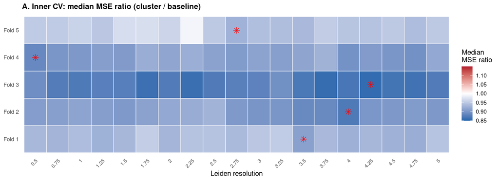

```r
# --- Panel A: inner-CV score for each resolution and fold ---
# resolution_scores is a named vector (names = Leiden resolutions); a score < 1
# means cluster features beat the titers-only baseline at that resolution.
heatmap_df <- do.call(rbind, lapply(1:n_folds, function(f) {
  scores <- fold_data[[f]]$resolution_scores
  data.frame(
    fold        = paste0("Fold ", f),
    resolution  = as.numeric(names(scores)),
    score       = as.numeric(scores),
    is_selected = abs(as.numeric(names(scores)) -
                        fold_data[[f]]$selected_resolution) < 0.01,
    stringsAsFactors = FALSE)
}))

p_a <- ggplot(heatmap_df, aes(factor(resolution), fold, fill = score)) +
  geom_tile(color = "white", linewidth = 0.3) +
  geom_point(data = subset(heatmap_df, is_selected),
             shape = 8, size = 3, color = "red", show.legend = FALSE) +
  scale_fill_gradient2(low = "#2166ac", mid = "white", high = "#b2182b",
                       midpoint = 1.0, name = "Median\nMSE ratio",
                       limits = c(min(heatmap_df$score, 0.85),
                                  max(heatmap_df$score, 1.15))) +
  labs(x = "Leiden resolution", y = NULL,
       title = "A. Inner CV: median MSE ratio (cluster / baseline)") +
  theme_minimal(base_size = 11) +
  theme(axis.text.x = element_text(angle = 45, hjust = 1, size = 8),
        plot.title = element_text(face = "bold", size = 12),
        panel.grid = element_blank())
p_a
```

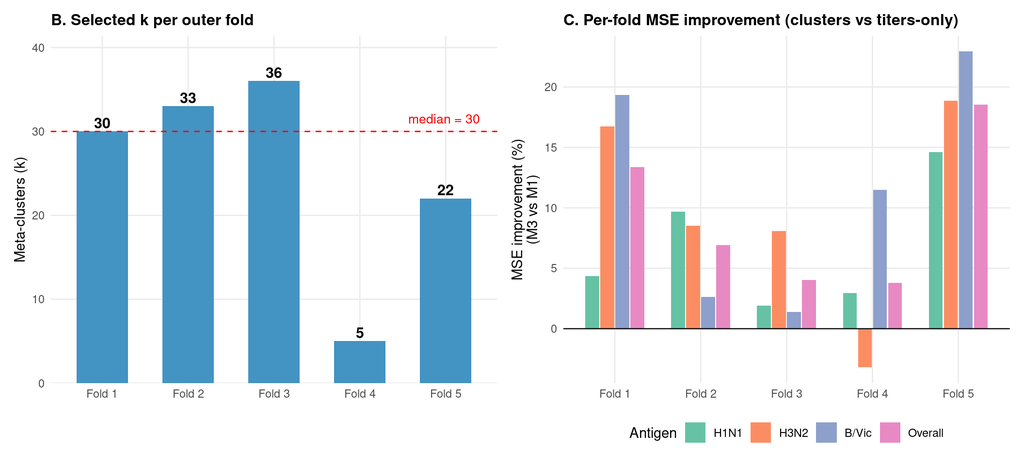

```r
# --- Panel B: number of meta-clusters (k) selected per outer fold ---
k_df <- data.frame(
  fold = paste0("Fold ", 1:n_folds),
  k    = vapply(1:n_folds, function(f) as.integer(fold_data[[f]]$k_found), integer(1)))

p_b <- ggplot(k_df, aes(fold, k)) +
  geom_col(fill = "#4393c3", width = 0.6) +
  geom_text(aes(label = k), vjust = -0.3, size = 4, fontface = "bold") +
  geom_hline(yintercept = median(k_df$k), linetype = "dashed", color = "red") +
  annotate("text", x = 5.4, y = median(k_df$k) + 1.5,
           label = paste0("median = ", median(k_df$k)),
           color = "red", hjust = 1, size = 3.5) +
  scale_y_continuous(expand = expansion(mult = c(0, 0.15))) +
  labs(x = NULL, y = "Meta-clusters (k)", title = "B. Selected k per outer fold") +
  theme_minimal(base_size = 11) +
  theme(plot.title = element_text(face = "bold", size = 12),
        panel.grid.minor = element_blank())

# --- Panel C: held-out MSE improvement of M3 over M1, per antigen and overall ---
perf_df <- do.call(rbind, lapply(1:n_folds, function(f) {
  e <- fold_data[[f]]
  Y  <- e$Y_test; p1 <- e$pred_M1_en_test; p3 <- e$pred_M3_en_test
  per_v <- do.call(rbind, lapply(colnames(Y), function(v) {
    data.frame(fold = paste0("Fold ", f), virus = toupper(v),
               improvement = 100 * (1 - mean((Y[, v] - p3[, v])^2) /
                                        mean((Y[, v] - p1[, v])^2)))
  }))
  overall <- data.frame(fold = paste0("Fold ", f), virus = "Overall",
                        improvement = 100 * (1 - mean((Y - p3)^2) / mean((Y - p1)^2)))
  rbind(per_v, overall)
}))
perf_df$virus <- gsub("BVIC", "B/Vic", perf_df$virus)
perf_df$virus <- factor(perf_df$virus, levels = c("H1N1", "H3N2", "B/Vic", "Overall"))

p_c <- ggplot(perf_df, aes(fold, improvement, fill = virus)) +
  geom_col(position = position_dodge(width = 0.7), width = 0.65) +
  geom_hline(yintercept = 0, linewidth = 0.4) +
  scale_fill_manual(values = c("H1N1" = "#66c2a5", "H3N2" = "#fc8d62",
                               "B/Vic" = "#8da0cb", "Overall" = "#e78ac3"),
                    name = "Antigen") +
  labs(x = NULL, y = "MSE improvement (%)\n(M3 vs M1)",
       title = "C. Per-fold MSE improvement (clusters vs titers-only)") +
  theme_minimal(base_size = 11) +
  theme(plot.title = element_text(face = "bold", size = 12),
        panel.grid.minor = element_blank(), legend.position = "bottom")

(p_b | p_c)
```

```r
# Selected k per fold and the median, as reported in the manuscript.
data.frame(Fold = 1:n_folds,
           Resolution = vapply(1:n_folds,
                               function(f) fold_data[[f]]$selected_resolution, numeric(1)),
           k = k_df$k)
```

```
##   Fold Resolution  k
## 1    1       3.50 30
## 2    2       4.00 33
## 3    3       4.25 36
## 4    4       0.50  5
## 5    5       2.75 22
```

```r
cat("\nMedian k across folds:", median(k_df$k), "\n")
```

```
##
## Median k across folds: 30
```

Four of the five folds select k in the 22–36 range (median 30); one fold selects a much smaller k, consistent with the flat inner-CV surface visible in Panel A, where scores stay below 1 across a wide band of resolutions. The cellular-composition features improve on the titers-only baseline in every fold (Panel C), which is the qualitative signal quantified formally in notebook 02.